# One-way ANOVA with Animation Illustration

Unit2: Analyzing Completely Randomized Design with a Single Categorial Factor

Longhai Li, University of Saskatchewan

January 2020

# 1 Read a dataset of animal coagulation time vs diet

```r
coagulation <- read.table("data/coagulation.txt", header=T)
coagulation
```

| coag | diet |
| --- | --- |
| 62 | A |
| 60 | A |
| 63 | A |
| 59 | A |
| 63 | B |
| 67 | B |
| 71 | B |
| 64 | B |
| 65 | B |
| 66 | B |
| 68 | C |
| 66 | C |
| 71 | C |
| 67 | C |
| 68 | C |
| 68 | C |
| 56 | D |
| 62 | D |
| 60 | D |
| 61 | D |
| 63 | D |
| 64 | D |
| 63 | D |
| 59 | D |

```r
coag <- coagulation$coag
diet <- coagulation$diet
```

# 2 Visualize the data using scatterplot and boxplot

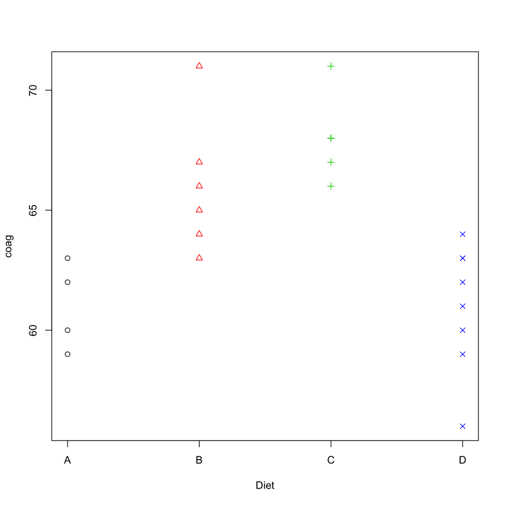

```r
plot (as.numeric(diet), coag,
      col = diet,
      pch = as.numeric(diet),
      xaxt="n", xlab = "Diet")
axis (1, 1:4, LETTERS[1:4])
```

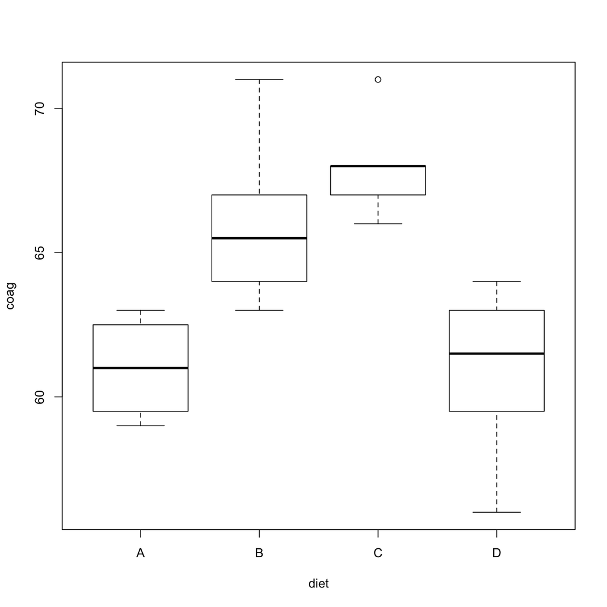

```r
boxplot(coag~diet)
```

# 3 Fit a Linear Model

## 3.1 Fit a linear model with cell means

```r
#
g0 <- lm(coag~0+diet)
# What model is fitted?
data.frame(coag,model.matrix(g0))
```

| coag | dietA | dietB | dietC | dietD |
| --- | --- | --- | --- | --- |
| 62 | 1 | 0 | 0 | 0 |
| 60 | 1 | 0 | 0 | 0 |
| 63 | 1 | 0 | 0 | 0 |
| 59 | 1 | 0 | 0 | 0 |
| 63 | 0 | 1 | 0 | 0 |
| 67 | 0 | 1 | 0 | 0 |
| 71 | 0 | 1 | 0 | 0 |
| 64 | 0 | 1 | 0 | 0 |
| 65 | 0 | 1 | 0 | 0 |
| 66 | 0 | 1 | 0 | 0 |
| 68 | 0 | 0 | 1 | 0 |
| 66 | 0 | 0 | 1 | 0 |
| 71 | 0 | 0 | 1 | 0 |
| 67 | 0 | 0 | 1 | 0 |
| 68 | 0 | 0 | 1 | 0 |
| 68 | 0 | 0 | 1 | 0 |
| 56 | 0 | 0 | 0 | 1 |
| 62 | 0 | 0 | 0 | 1 |
| 60 | 0 | 0 | 0 | 1 |
| 61 | 0 | 0 | 0 | 1 |
| 63 | 0 | 0 | 0 | 1 |
| 64 | 0 | 0 | 0 | 1 |
| 63 | 0 | 0 | 0 | 1 |
| 59 | 0 | 0 | 0 | 1 |

This model is written as:
$$y_k = \mu_A x_k^A+\mu_B x_k^B+\mu_C x_k^C+\mu_D x_k^D+\epsilon_k$$
where $x_k^i=I(x_k=i)$ for $i=A,B,C,D$.

```r
# The model fitting results:
summary(g0)
```

```
#
# Call:
# lm(formula = coag ~ 0 + diet)
#
# Residuals:
#    Min     1Q Median     3Q    Max
#  -5.00  -1.25   0.00   1.25   5.00
#
# Coefficients:
#       Estimate Std. Error t value Pr(>|t|)
# dietA   61.000      1.183    51.5   <2e-16 ***
# dietB   66.000      0.966    68.3   <2e-16 ***
# dietC   68.000      0.966    70.4   <2e-16 ***
# dietD   61.000      0.837    72.9   <2e-16 ***
# ---
# Signif. codes:  0 '***' 0.001 '**' 0.01 '*' 0.05 '.' 0.1 ' ' 1
#
# Residual standard error: 2.37 on 20 degrees of freedom
# Multiple R-squared:  0.999,   Adjusted R-squared:  0.999
# F-statistic: 4.4e+03 on 4 and 20 DF,  p-value: <2e-16
```

## 3.2 Fit a linear model with centralized effects

```r
#
g3 <- lm(coag~diet, contrasts = list(diet=contr.sum))

# What model is fitted?
data.frame(coag, model.matrix(g3))
```

| coag | X.Intercept. | diet1 | diet2 | diet3 |
| --- | --- | --- | --- | --- |
| 62 | 1 | 1 | 0 | 0 |
| 60 | 1 | 1 | 0 | 0 |
| 63 | 1 | 1 | 0 | 0 |
| 59 | 1 | 1 | 0 | 0 |
| 63 | 1 | 0 | 1 | 0 |
| 67 | 1 | 0 | 1 | 0 |
| 71 | 1 | 0 | 1 | 0 |
| 64 | 1 | 0 | 1 | 0 |
| 65 | 1 | 0 | 1 | 0 |
| 66 | 1 | 0 | 1 | 0 |
| 68 | 1 | 0 | 0 | 1 |
| 66 | 1 | 0 | 0 | 1 |
| 71 | 1 | 0 | 0 | 1 |
| 67 | 1 | 0 | 0 | 1 |
| 68 | 1 | 0 | 0 | 1 |
| 68 | 1 | 0 | 0 | 1 |
| 56 | 1 | -1 | -1 | -1 |
| 62 | 1 | -1 | -1 | -1 |
| 60 | 1 | -1 | -1 | -1 |
| 61 | 1 | -1 | -1 | -1 |
| 63 | 1 | -1 | -1 | -1 |
| 64 | 1 | -1 | -1 | -1 |
| 63 | 1 | -1 | -1 | -1 |
| 59 | 1 | -1 | -1 | -1 |

This model is written as:
$$y_k = \mu+\tau_A (x_k^A-x_k^D)+\tau_B (x_k^B-x_k^D)+\tau_C (x_k^C-x_k^D)+\epsilon_k$$
where
$$\mu=(\mu_A+\ldots+\mu_D)/4, \tau_A=\mu_A-\mu,\ldots,\tau_D=\mu_D-\mu$$

```r
## fitting results
summary(g3)
```

```
#
# Call:
# lm(formula = coag ~ diet, contrasts = list(diet = contr.sum))
#
# Residuals:
#    Min     1Q Median     3Q    Max
#  -5.00  -1.25   0.00   1.25   5.00
#
# Coefficients:
#             Estimate Std. Error t value Pr(>|t|)
# (Intercept)   64.000      0.498  128.54  < 2e-16 ***
# diet1         -3.000      0.974   -3.08  0.00589 **
# diet2          2.000      0.845    2.37  0.02819 *
# diet3          4.000      0.845    4.73  0.00013 ***
# ---
# Signif. codes:  0 '***' 0.001 '**' 0.01 '*' 0.05 '.' 0.1 ' ' 1
#
# Residual standard error: 2.37 on 20 degrees of freedom
# Multiple R-squared:  0.671,   Adjusted R-squared:  0.621
# F-statistic: 13.6 on 3 and 20 DF,  p-value: 4.66e-05
```

## 3.3 Fit a linear model with treatment differences

```r
#
g <- lm(coag~diet, contrasts = list(diet=contr.treatment(n=4,base = 1)))

# What model is fitted?
data.frame(model.matrix(g))
```

| X.Intercept. | diet2 | diet3 | diet4 |
| --- | --- | --- | --- |
| 1 | 0 | 0 | 0 |
| 1 | 0 | 0 | 0 |
| 1 | 0 | 0 | 0 |
| 1 | 0 | 0 | 0 |
| 1 | 1 | 0 | 0 |
| 1 | 1 | 0 | 0 |
| 1 | 1 | 0 | 0 |
| 1 | 1 | 0 | 0 |
| 1 | 1 | 0 | 0 |
| 1 | 1 | 0 | 0 |
| 1 | 0 | 1 | 0 |
| 1 | 0 | 1 | 0 |
| 1 | 0 | 1 | 0 |
| 1 | 0 | 1 | 0 |
| 1 | 0 | 1 | 0 |
| 1 | 0 | 1 | 0 |
| 1 | 0 | 0 | 1 |
| 1 | 0 | 0 | 1 |
| 1 | 0 | 0 | 1 |
| 1 | 0 | 0 | 1 |
| 1 | 0 | 0 | 1 |
| 1 | 0 | 0 | 1 |
| 1 | 0 | 0 | 1 |
| 1 | 0 | 0 | 1 |

This model is written as:
$$y_k = \beta_0+\beta_B x_k^B+\beta_Cx_k^C+\beta_D x_k^D+\epsilon_k$$
where,
$$\beta_0=\mu_A, \beta_B=\mu_B-\mu_A, \beta_C=\mu_C-\mu_A, \beta_D=\mu_D-\mu_A.$$
Note that
$$\beta_B=\tau_B-\tau_A,\beta_C=\tau_C-\tau_A,\beta_D=\tau_D-\tau_A.$$

```r
## fitting results
summary(g)
```

```
#
# Call:
# lm(formula = coag ~ diet, contrasts = list(diet = contr.treatment(n = 4,
#     base = 1)))
#
# Residuals:
#    Min     1Q Median     3Q    Max
#  -5.00  -1.25   0.00   1.25   5.00
#
# Coefficients:
#             Estimate Std. Error t value Pr(>|t|)
# (Intercept) 6.10e+01   1.18e+00   51.55  < 2e-16 ***
# diet2       5.00e+00   1.53e+00    3.27  0.00380 **
# diet3       7.00e+00   1.53e+00    4.58  0.00018 ***
# diet4       2.99e-15   1.45e+00    0.00  1.00000
# ---
# Signif. codes:  0 '***' 0.001 '**' 0.01 '*' 0.05 '.' 0.1 ' ' 1
#
# Residual standard error: 2.37 on 20 degrees of freedom
# Multiple R-squared:  0.671,   Adjusted R-squared:  0.621
# F-statistic: 13.6 on 3 and 20 DF,  p-value: 4.66e-05
```

```r
## by default, R uses this mean difference parametrization
gd <- lm(coag~diet)

summary(gd)
```

```
#
# Call:
# lm(formula = coag ~ diet)
#
# Residuals:
#    Min     1Q Median     3Q    Max
#  -5.00  -1.25   0.00   1.25   5.00
#
# Coefficients:
#             Estimate Std. Error t value Pr(>|t|)
# (Intercept) 6.10e+01   1.18e+00   51.55  < 2e-16 ***
# dietB       5.00e+00   1.53e+00    3.27  0.00380 **
# dietC       7.00e+00   1.53e+00    4.58  0.00018 ***
# dietD       2.99e-15   1.45e+00    0.00  1.00000
# ---
# Signif. codes:  0 '***' 0.001 '**' 0.01 '*' 0.05 '.' 0.1 ' ' 1
#
# Residual standard error: 2.37 on 20 degrees of freedom
# Multiple R-squared:  0.671,   Adjusted R-squared:  0.621
# F-statistic: 13.6 on 3 and 20 DF,  p-value: 4.66e-05
```

# 4 Analysis of Variance

## 4.1 Fitted values, Residuals, and Sum Squares

This section is for illustrating prediction and residuals

```r
y <- coag
y_hat_h0 <- rep (mean (y), length (y)); y_hat_h0
```

```
#  [1] 64 64 64 64 64 64 64 64 64 64 64 64 64 64 64 64 64 64 64 64 64 64 64 64
```

```r
y_hat_h1 <- predict (lm (y~diet)); y_hat_h1;
```

```
#  1  2  3  4  5  6  7  8  9 10 11 12 13 14 15 16 17 18 19 20 21 22 23 24
# 61 61 61 61 66 66 66 66 66 66 68 68 68 68 68 68 61 61 61 61 61 61 61 61
```

```r
# residual (error) from h0 model (equal means)
resid_h0 <- y - y_hat_h0
# residual (error) from h1 model (unequal means)
resid_h1 <- y - y_hat_h1
data.frame (diet, y=y, y_hat_h0, resid_h0, y_hat_h1, resid_h1, diff.residual=y_hat_h1-y_hat_h0 )
```

| diet | y | y_hat_h0 | resid_h0 | y_hat_h1 | resid_h1 | diff.residual |
| --- | --- | --- | --- | --- | --- | --- |
| A | 62 | 64 | -2 | 61 | 1 | -3 |
| A | 60 | 64 | -4 | 61 | -1 | -3 |
| A | 63 | 64 | -1 | 61 | 2 | -3 |
| A | 59 | 64 | -5 | 61 | -2 | -3 |
| B | 63 | 64 | -1 | 66 | -3 | 2 |
| B | 67 | 64 | 3 | 66 | 1 | 2 |
| B | 71 | 64 | 7 | 66 | 5 | 2 |
| B | 64 | 64 | 0 | 66 | -2 | 2 |
| B | 65 | 64 | 1 | 66 | -1 | 2 |
| B | 66 | 64 | 2 | 66 | 0 | 2 |
| C | 68 | 64 | 4 | 68 | 0 | 4 |
| C | 66 | 64 | 2 | 68 | -2 | 4 |
| C | 71 | 64 | 7 | 68 | 3 | 4 |
| C | 67 | 64 | 3 | 68 | -1 | 4 |
| C | 68 | 64 | 4 | 68 | 0 | 4 |
| C | 68 | 64 | 4 | 68 | 0 | 4 |
| D | 56 | 64 | -8 | 61 | -5 | -3 |
| D | 62 | 64 | -2 | 61 | 1 | -3 |
| D | 60 | 64 | -4 | 61 | -1 | -3 |
| D | 61 | 64 | -3 | 61 | 0 | -3 |
| D | 63 | 64 | -1 | 61 | 2 | -3 |
| D | 64 | 64 | 0 | 61 | 3 | -3 |
| D | 63 | 64 | -1 | 61 | 2 | -3 |
| D | 59 | 64 | -5 | 61 | -2 | -3 |

**Visulize the predictive values and residuals**

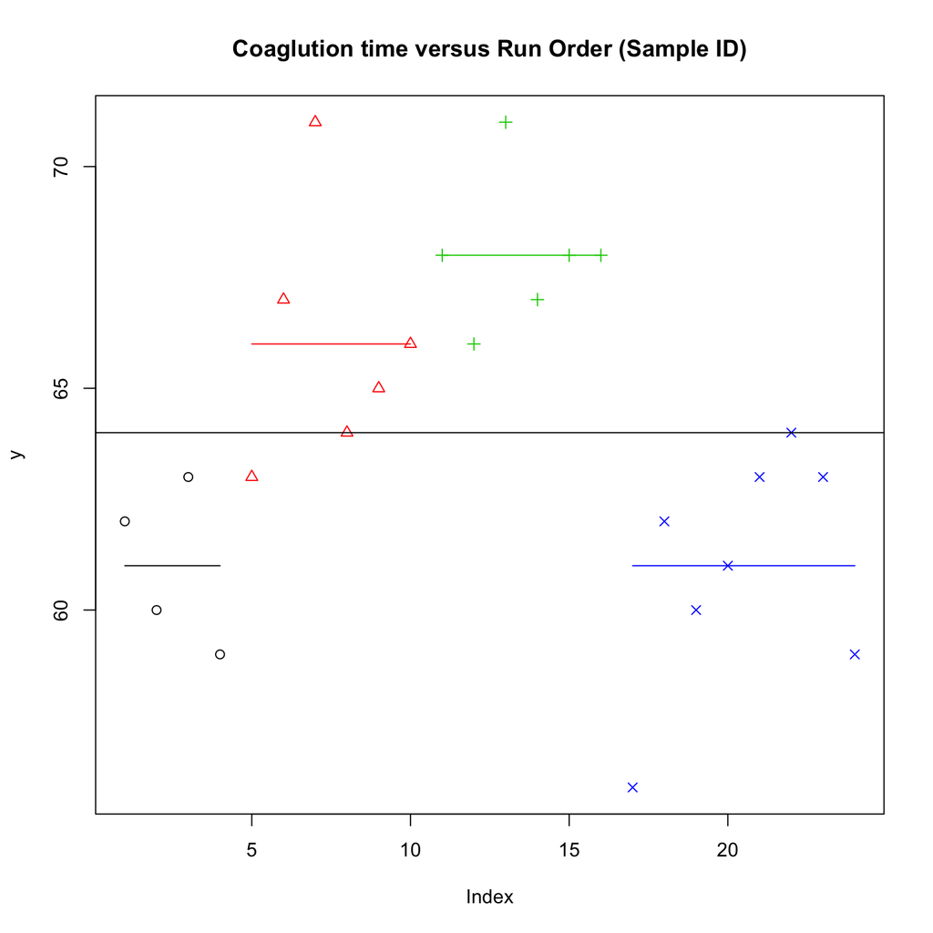

```r
plot (y, col = diet,pch = as.numeric(diet),
      main="Coaglution time versus Run Order (Sample ID)")
lines (1:4,g$fitted.values[1:4], col = 1)
lines (5:10,g$fitted.values[5:10], col = 2)
lines (11:16,g$fitted.values[11:16], col = 3)
lines (17:24,g$fitted.values[17:24], col = 4)
abline(h=mean(y))
```

```r
# compute SS
SSt <-sum((y - y_hat_h0)^2); SSt
```

```
# [1] 340
```

```r
SSe <- sum((y - y_hat_h1)^2); SSe
```

```
# [1] 112
```

```r
SStr <- SSt - SSe; SStr # alternatively we can compute SStr by
```

```
# [1] 228
```

```r
SStr2 <- sum((y_hat_h0-y_hat_h1)^2); SStr2
```

```
# [1] 228
```

**Plot of Sum Square Against Degree Freedom**

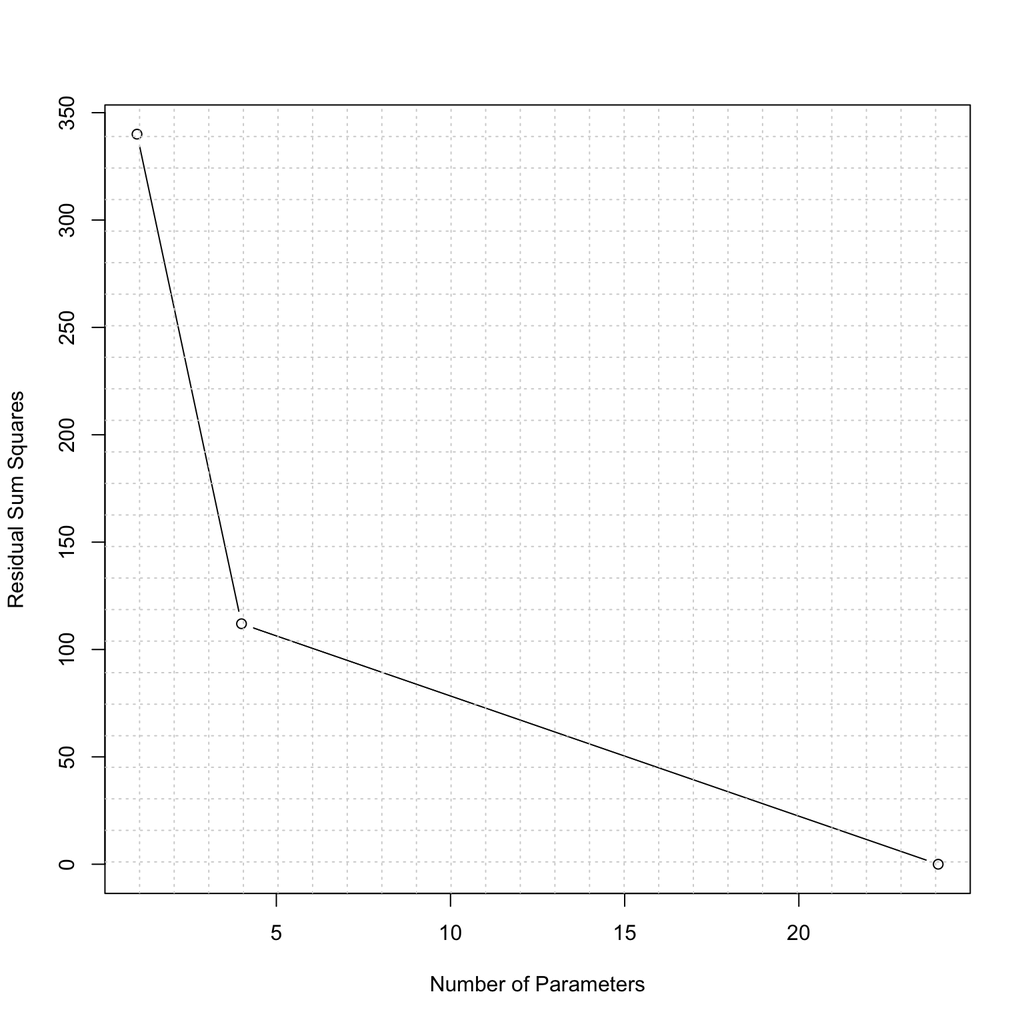

```r
rss <- c(SSt, SSe,0)
num.par <- c(1, 4, n=nrow(coagulation))
plot(rss~num.par, xlab = "Number of Parameters", ylab = "Residual Sum Squares", type="b")
grid(nx=5*5)
```

## 4.2 ANOVA by Hand (Short-cut Formula)

Let $n=n_1+\ldots,n_a$ with $n_i$ is the number of observation in group $i$. Formulae for computing SS:
$$RSS_0 = SST = \sum_{i,j} y_{ij}^2-n\bar{y_{..}}^2$$
$$RSS_0-RSS_1 = SS_{tr} = \sum_i^a n_i\bar{y}_{i.}^2-n\bar{y_{..}}^2$$
$$RSS_1 = SSE=SST-SS_{tr}=\sum_{i,j} y_{ij}^2 - \sum_i^a n_i\bar{y}_{i.}^2 = \sum_i^a SS_i$$

```r
ybar_i. <- tapply (y, mean, INDEX = diet); ybar_i.
```

```
#  A  B  C  D
# 61 66 68 61
```

```r
ybar_.. <- mean (y); ybar_..
```

```
# [1] 64
```

```r
n_i <- table (diet); n_i
```

```
# diet
# A B C D
# 4 6 6 8
```

```r
n <- length (y)
SSy <- sum (y^2)
# the above values will be provided in test question

# compute SSt,SSe, SStr
SSt <- SSy-n*ybar_..^2; SSt
```

```
# [1] 340
```

```r
n_i*ybar_i.^2 # vectoized calculation
```

```
# diet
#     A     B     C     D
# 14884 26136 27744 29768
```

```r
SStr <- sum(n_i*ybar_i.^2) - n*ybar_..^2; SStr
```

```
# [1] 228
```

```r
SSe <- SSt - SStr; SSe
```

```
# [1] 112
```

```r
# compute F and output anova table
k <- length (unique (diet));k
```

```
# [1] 4
```

```r
n <- length (y);n
```

```
# [1] 24
```

```r
df1 <- k - 1
df2 <- n - k
MStr <- SStr/df1
MSe <- SSe/df2
f <- MStr /MSe
pvalue <- 1-pf (f, df1=df1, df2=df2); pvalue
```

```
# [1] 4.658e-05
```

```r
anova_table <- data.frame (Df = c(df1,df2),
                           SS = c(SStr,SSe),
                           MS = c(MStr, MSe),
                           F = c(f,NA),
                           pvalue = c(pvalue, NA));
row.names(anova_table) <- c("diet", "Residuals")
anova_table
```

|  | Df | SS | MS | F | pvalue |
| --- | --- | --- | --- | --- | --- |
| diet | 3 | 228 | 76.0 | 13.57 | 0 |
| Residuals | 20 | 112 | 5.6 | NA | NA |

## 4.3 ANOVA with R Function

Compute ANOVA with the fitting result with intercept

```r
g <- lm(coag~diet)
anova (g)
```

|  | Df | Sum Sq | Mean Sq | F value | Pr(>F) |
| --- | --- | --- | --- | --- | --- |
| diet | 3 | 228 | 76.0 | 13.57 | 0 |
| Residuals | 20 | 112 | 5.6 | NA | NA |

## 4.4 Understanding Sampling Distribution of SS and F

We will use simulation to understand the sampling distributions of sum squares and F statistics in ANOVA.

**When treat difference is 0**

```r
g <- lm (coag~diet)
n <- nrow (coagulation)
g$coefficients[2:4] <- 0
ylim0 <- range (coag) + c(-2,2)
```

```r
# Simulate datasets with modified coeffients
for(i in 1:100){
  sim.coag <- predict(g, newdata = coagulation)+rnorm(n,0,2.37)
  par(mfrow=c(1,2))
  plot(sim.coag~as.numeric(diet),
       col=as.numeric(diet),
       xlab = "Diet",
       ylab = "Simulated Response",
       ylim = ylim0)
  fit.sim.coag <- lm(sim.coag~diet)
  anova.fit.sim.coag <- anova(fit.sim.coag)
  ss.sim.coag <- anova.fit.sim.coag$`Sum Sq`
  rss.sim.coag <- rev(cumsum(c(0, rev(ss.sim.coag))))
  num.par <- cumsum(c(1,anova.fit.sim.coag$Df))
  plot(rss.sim.coag~num.par,
       xlab="Number of Parameters",
       ylab = "Residual Sum Squares",
       type ="b",
       main=sprintf("F=%.2f",anova.fit.sim.coag$`F value`[1])
       )

  grid(nx=25)
}
```

[video not shown]

**When treat difference is non-zero**

```r
g <- lm (coag~diet)
n <- nrow (coagulation)
g$coefficients[2:4] <- c(1,2,3)*3
ylim0 <- range (coag) + c(-2,5)
```

```r
# Simulate datasets with modified coeffients
for(i in 1:100){
  sim.coag <- predict(g, newdata = coagulation)+rnorm(n,0,2.37)
  par(mfrow=c(1,2))
  plot(sim.coag~as.numeric(diet),
       col=as.numeric(diet),
       xlab = "Diet",
       ylab = "Simulated Response",
       ylim = ylim0)
  fit.sim.coag <- lm(sim.coag~diet)
  anova.fit.sim.coag <- anova(fit.sim.coag)
  ss.sim.coag <- anova.fit.sim.coag$`Sum Sq`
  rss.sim.coag <- rev(cumsum(c(0, rev(ss.sim.coag))))
  num.par <- cumsum(c(1,anova.fit.sim.coag$Df))
  plot(rss.sim.coag~num.par,
       xlab="Number of Parameters",
       ylab = "Residual Sum Squares",
       type ="b",
       main=sprintf("F=%.2f",anova.fit.sim.coag$`F value`[1])
  )
  grid(nx=25)
}
```

[video not shown]

# 5 Model Checking

```r
## fit lm model
g <- lm(coag~diet)
summary (g)
```

```
#
# Call:
# lm(formula = coag ~ diet)
#
# Residuals:
#    Min     1Q Median     3Q    Max
#  -5.00  -1.25   0.00   1.25   5.00
#
# Coefficients:
#             Estimate Std. Error t value Pr(>|t|)
# (Intercept) 6.10e+01   1.18e+00   51.55  < 2e-16 ***
# dietB       5.00e+00   1.53e+00    3.27  0.00380 **
# dietC       7.00e+00   1.53e+00    4.58  0.00018 ***
# dietD       2.99e-15   1.45e+00    0.00  1.00000
# ---
# Signif. codes:  0 '***' 0.001 '**' 0.01 '*' 0.05 '.' 0.1 ' ' 1
#
# Residual standard error: 2.37 on 20 degrees of freedom
# Multiple R-squared:  0.671,   Adjusted R-squared:  0.621
# F-statistic: 13.6 on 3 and 20 DF,  p-value: 4.66e-05
```

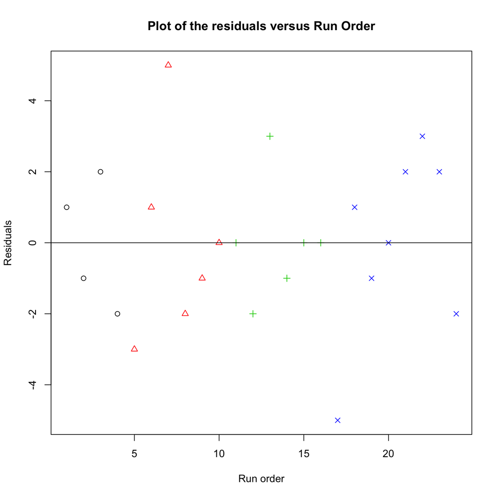

```r
## plot residuals vs run order
plot(g$residuals,
     xlab="Run order", ylab="Residuals",
     main="Plot of the residuals versus Run Order",
     col = diet, pch = as.numeric(diet))
abline (h=0)
```

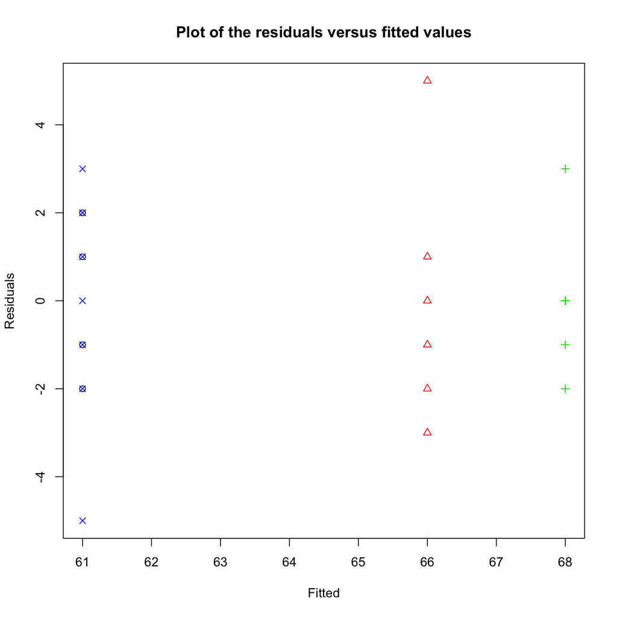

```r
# check the constant variance assumption
plot(g$fit,g$residuals,
     xlab="Fitted",ylab="Residuals",
     main="Plot of the residuals versus fitted values",
     col = diet,
     pch = as.numeric(diet))
```

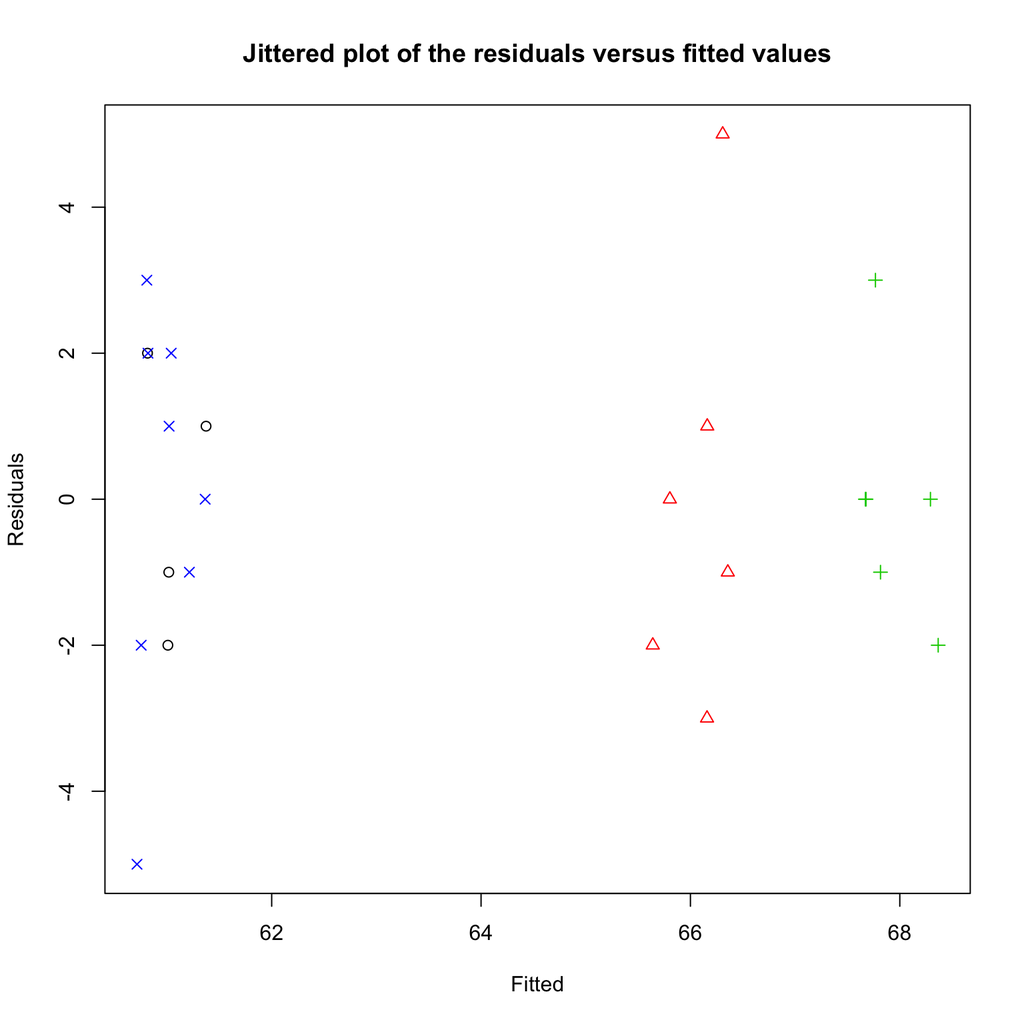

```r
## add some jitter since the fitted value for diet A and D are the same
plot(jitter(g$fit), g$residuals, xlab="Fitted",ylab="Residuals",
     main="Jittered plot of the residuals versus fitted values",
     col = diet,
     pch = as.numeric(diet))
```

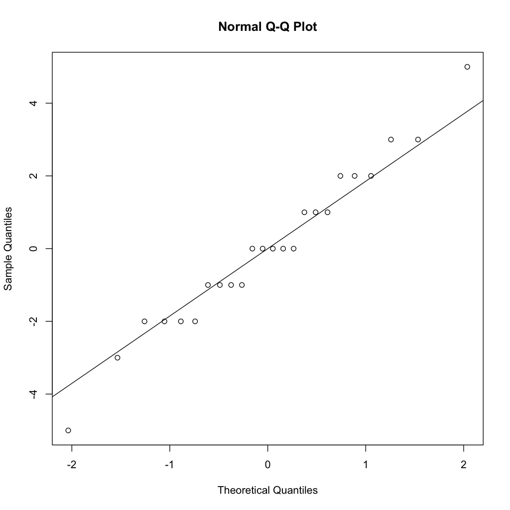

```r
## draw qq plot to check normality of residuals
qqnorm(g$residuals)
qqline(g$residuals)
```

```r
## testing normality of residuals
shapiro.test(g$residuals)
```

```
#
#   Shapiro-Wilk normality test
#
# data:  g$residuals
# W = 0.98, p-value = 0.9
```

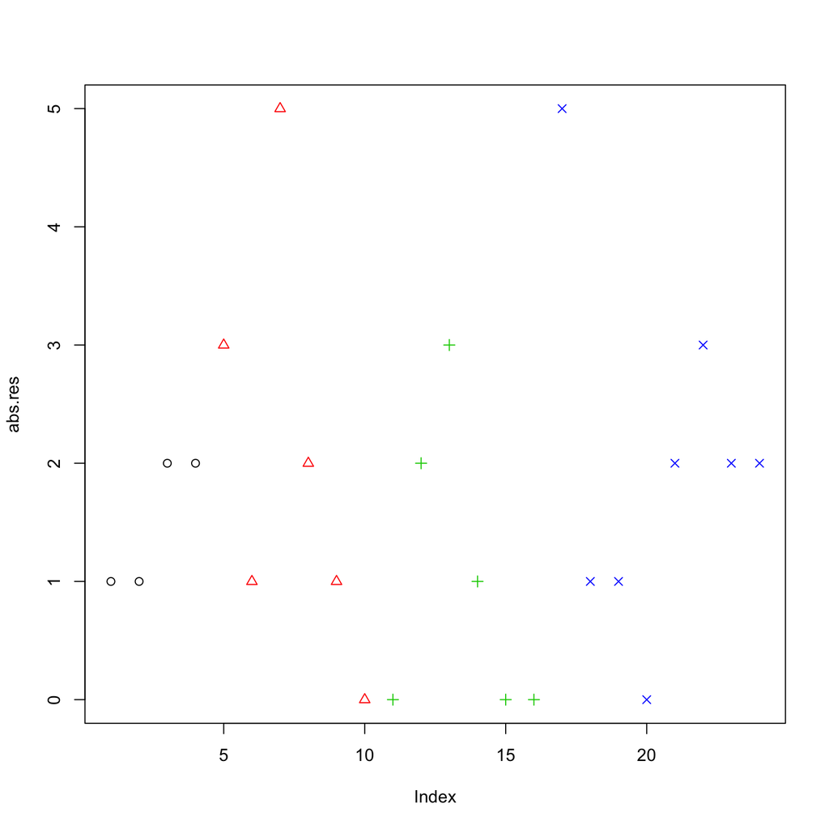

```r
# checking equality of variances
## an illustration
abs.res <- abs(g$residuals)
plot (abs.res, pch = as.numeric(diet), col = diet)
```

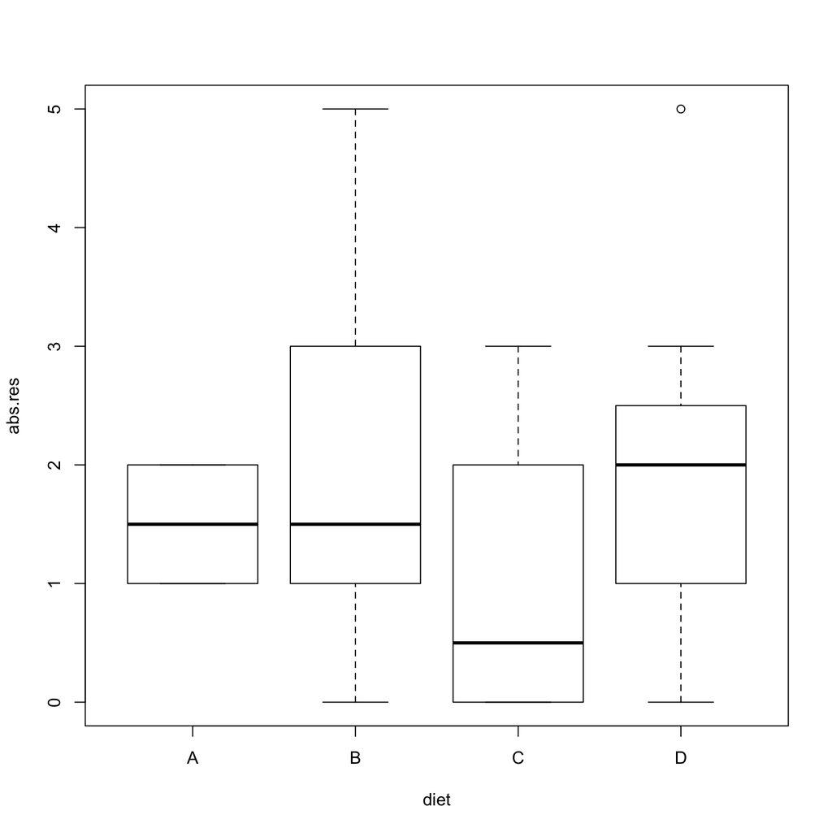

```r
boxplot (abs.res~diet)
```

```r
anova (lm (abs.res~diet))
```

|  | Df | Sum Sq | Mean Sq | F value | Pr(>F) |
| --- | --- | --- | --- | --- | --- |
| diet | 3 | 4.333 | 1.444 | 0.7046 | 0.5604 |
| Residuals | 20 | 41.000 | 2.050 | NA | NA |

```r
## traditional levene test is as above
levene.test(coagulation$coag, coagulation$diet, location = "mean")
```

```
#
#   Classical Levene's test based on the absolute deviations from the mean
#   ( none not applied because the location is not set to median )
#
# data:  coagulation$coag
# Test Statistic = 0.7, p-value = 0.6
```

```r
## modified levene test is to substitute the means by medians
levene.test(coagulation$coag, coagulation$diet, location = "median")
```

```
#
#   Modified robust Brown-Forsythe Levene-type test based on the absolute
#   deviations from the median
#
# data:  coagulation$coag
# Test Statistic = 0.65, p-value = 0.6
```

```r
#Bartlette's test
bartlett.test(coag~diet, coagulation)
```

```
#
#   Bartlett test of homogeneity of variances
#
# data:  coag by diet
# Bartlett's K-squared = 1.7, df = 3, p-value = 0.6
```

# 6 Comparing Effects

## 6.1 Estimate Treatment Means

```r
g <- lm (coag~0+diet)
cbind(summary(g)$coefficients,confint (g))
```

```
#       Estimate Std. Error t value  Pr(>|t|) 2.5 % 97.5 %
# dietA       61     1.1832   51.55 9.548e-23 58.53  63.47
# dietB       66     0.9661   68.32 3.532e-25 63.98  68.02
# dietC       68     0.9661   70.39 1.949e-25 65.98  70.02
# dietD       61     0.8367   72.91 9.663e-26 59.25  62.75
```

Computing formular for standard error:
$$\hat\sigma=\sqrt{MSE}$$
$$se(\hat \mu_i)=\hat\sigma\times \sqrt{1/n_i}$$

```r
## get MSE from ANOVA output
anova(g)
```

|  | Df | Sum Sq | Mean Sq | F value | Pr(>F) |
| --- | --- | --- | --- | --- | --- |
| diet | 4 | 98532 | 24633.0 | 4399 | 0 |
| Residuals | 20 | 112 | 5.6 | NA | NA |

```r
table(diet)
```

```
# diet
# A B C D
# 4 6 6 8
```

```r
sigma <- sqrt(5.6); sigma
```

```
# [1] 2.366
```

```r
se_mu1 <- sigma * sqrt(1/4)
me_mu1 <- se_mu1 * qt(0.975, df = 20)
CI <- 61 + c(-me_mu1,me_mu1); CI
```

```
# [1] 58.53 63.47
```

```r
se_mu2 <- sigma * sqrt(1/6)
me_mu2 <- se_mu2 * qt(0.975, df = 20)
CI <- 66 + c(-me_mu2,me_mu2); CI
```

```
# [1] 63.98 68.02
```

## 6.2 Effect Comparison with Least Significant Difference

Simply using confidence intervals from lm model, which uses t quantile without using multiple comparison adjustment, and use “A” as the baseline level (intercept)

```r
g <- lm (coag~diet)
cbind(summary(g)$coefficients,confint (g))
```

```
#              Estimate Std. Error   t value  Pr(>|t|)  2.5 % 97.5 %
# (Intercept) 6.100e+01      1.183 5.155e+01 9.548e-23 58.532 63.468
# dietB       5.000e+00      1.528 3.273e+00 3.803e-03  1.814  8.186
# dietC       7.000e+00      1.528 4.583e+00 1.805e-04  3.814 10.186
# dietD       2.991e-15      1.449 2.064e-15 1.000e+00 -3.023  3.023
```

Computing formula for standard error:
$$se(\hat \mu_i-\hat \mu_j)=\hat\sigma\times \sqrt{1/n_i+1/n_j}$$

```r
anova(g)
```

|  | Df | Sum Sq | Mean Sq | F value | Pr(>F) |
| --- | --- | --- | --- | --- | --- |
| diet | 3 | 228 | 76.0 | 13.57 | 0 |
| Residuals | 20 | 112 | 5.6 | NA | NA |

```r
table(diet)
```

```
# diet
# A B C D
# 4 6 6 8
```

```r
sigma <- sqrt(5.6); sigma
```

```
# [1] 2.366
```

```r
se_mu1_to_mu2 <- sigma * sqrt(1/4+1/6)
me_mu1_to_mu2 <- se_mu1_to_mu2 * qt(0.975, df = 20)
CI <- 66-61 + c(-me_mu1_to_mu2,me_mu1_to_mu2); CI
```

```
# [1] 1.814 8.186
```

```r
se_mu1_to_mu4 <- sigma * sqrt(1/4+1/8)
me_mu1_to_mu4 <- se_mu1_to_mu4 * qt(0.975, df = 20)
CI <- 61-61 + c(-me_mu1_to_mu4,me_mu1_to_mu4); CI
```

```
# [1] -3.023  3.023
```

## 6.3 A Simulation Illustration for Multiple Comparison Bias

```r
k <- 6 ## number of means
rep_means <- replicate (k, rnorm(10000))/sqrt(rchisq(10000, df =20)/20)
rep_means[1:10,]
```

```
#           [,1]    [,2]      [,3]     [,4]    [,5]     [,6]
#  [1,]  0.07936 -1.1155 -0.345271  0.52322  1.0142 -1.40514
#  [2,]  0.73488  1.7361  0.007894  0.24220  0.5333  1.17966
#  [3,] -0.89140 -0.7483 -0.201237 -0.85505 -0.3195 -0.02718
#  [4,] -0.31502 -1.5270 -0.097061  0.67787 -0.3831 -0.70941
#  [5,]  0.52082  1.3273  0.075378  1.46701  0.7047 -0.13058
#  [6,] -0.21127  1.2140 -1.113065  0.69077 -0.7042  1.80166
#  [7,]  0.32672 -2.3090  0.892029  1.25368 -0.1084  1.57682
#  [8,] -0.24332 -0.8896  0.350715 -3.32672 -0.2094 -0.03835
#  [9,]  0.30136  1.1280  0.429686 -0.42425  0.5074 -0.20134
# [10,]  0.48439  1.4437 -1.053625  0.03308  0.7985 -0.97384
```

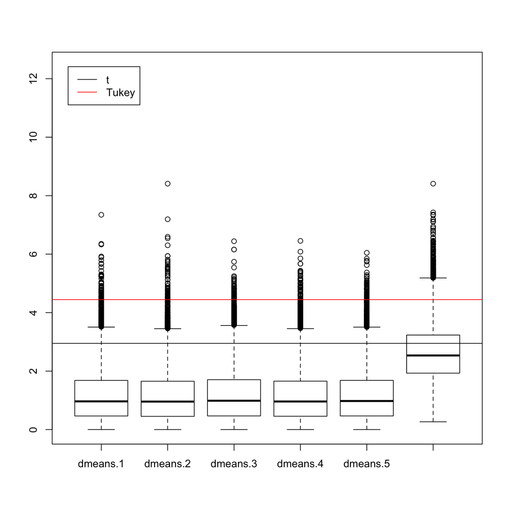

```r
ranget <- function (x) {max (x)-min(x)}
rep_means_max <- apply(rep_means, 1, ranget)
sim.diff.means <- data.frame (dmeans=abs(rep_means[,-1]-rep_means[,1]),
                              max_difference=rep_means_max)
#sim.data[1:10,]
ylim <- c(0, max (sim.diff.means)+4)
boxplot (sim.diff.means, ylim = ylim)
abline (h = qt(0.975,df = 20)* sqrt(2))
abline (h = qtukey(0.95, nmeans = k, df = 20), col = "red")
legend(0.5, ylim[2],
       c("t", "Tukey"), lty = c(1,1),col = 1:2)
```

## 6.4 Quantiles in Tukey, Bonferroni Correction and t

In hand calculation,considering multiple comparison, the t quantile should be replaced by tukey quantile/sqrt(2)

```r
qt0 <- qt (0.975, df = 20)
qk <- qb <- rep (0,4)
qk [1]  <- qtukey(0.95, nmeans = 2, df =20 )/sqrt(2) ## nmeans is number of means
qk [2]  <- qtukey(0.95, nmeans = 4, df =20 )/sqrt(2) ## nmeans is number of means
qk [3]  <- qtukey(0.95, nmeans = 40, df =20 )/sqrt(2) ## nmeans is number of means
qk [4]  <- qtukey(0.95, nmeans = 100, df =20 )/sqrt(2) ## nmeans is number of means
## comparing to bonferroni correction
qb[1] <- qt (1-0.025/choose (2,2), df = 20)
qb[2] <- qt (1-0.025/choose (4,2), df = 20)
qb[3] <- qt (1-0.025/choose (40,2), df = 20)
qb[4] <- qt (1-0.025/choose (100,2), df = 20)

comp.qtb <- data.frame(t = qt0,  Tukey = qk, Bonferroni = qb )
row.names(comp.qtb) <- paste0("number of means = ", c(2,4,40,100))
comp.qtb
```

|  | t | Tukey | Bonferroni |
| --- | --- | --- | --- |
| number of means = 2 | 2.086 | 2.086 | 2.086 |
| number of means = 4 | 2.086 | 2.799 | 2.927 |
| number of means = 40 | 2.086 | 4.506 | 5.030 |
| number of means = 100 | 2.086 | 5.082 | 5.849 |

## 6.5 Procedure for Computing Tukey Confidence Intervals

```r
## explanation for how to compute the tukey CI for dietA - diet B
g <- lm (coag~diet)
anova.g <- anova (g)
dietMeans <- g$coefficients[1] + c(0, g$coefficients[-1]) ## or using
dietMeans <- tapply (coag, INDEX = diet, mean)
sigma <- sigma (g); sigma
```

```
# [1] 2.366
```

```r
diet_n <- table (diet); diet_n
```

```
# diet
# A B C D
# 4 6 6 8
```

Formula for Tukey Margin Error with confidence level $1-\alpha$:

$$\hat\sigma \times \sqrt {1/n_i+1/n_j} \times q_{\alpha, k, df}/\sqrt{2}$$
where $q_{\alpha, k, df}$ is the **upper** tukey quantile with $k$ means and $df$ degrees freedom.

```r
ME_tukey <- sigma * sqrt (1/diet_n[1]+1/diet_n[2]) * qtukey(0.95, 4, 20)/sqrt(2)
CI <- (dietMeans[2]-dietMeans[1]) + c(-ME_tukey,ME_tukey); names (CI) = c("lower", "upper"); CI
```

```
#  lower  upper
# 0.7246 9.2754
```

```r
## In R, you can use this function
dmeans.tukey <- TukeyHSD(aov (coag~diet)); dmeans.tukey
```

```
#   Tukey multiple comparisons of means
#     95% family-wise confidence level
#
# Fit: aov(formula = coag ~ diet)
#
# $diet
#     diff      lwr    upr  p adj
# B-A    5   0.7246  9.275 0.0183
# C-A    7   2.7246 11.275 0.0010
# D-A    0  -4.0560  4.056 1.0000
# C-B    2  -1.8241  5.824 0.4766
# D-B   -5  -8.5771 -1.423 0.0044
# D-C   -7 -10.5771 -3.423 0.0001
```

```r
## Comparing with LSD CIs
g <- lm (coag~diet)
cbind(summary(g)$coefficients,confint (g))
```

```
#              Estimate Std. Error   t value  Pr(>|t|)  2.5 % 97.5 %
# (Intercept) 6.100e+01      1.183 5.155e+01 9.548e-23 58.532 63.468
# dietB       5.000e+00      1.528 3.273e+00 3.803e-03  1.814  8.186
# dietC       7.000e+00      1.528 4.583e+00 1.805e-04  3.814 10.186
# dietD       2.991e-15      1.449 2.064e-15 1.000e+00 -3.023  3.023
```

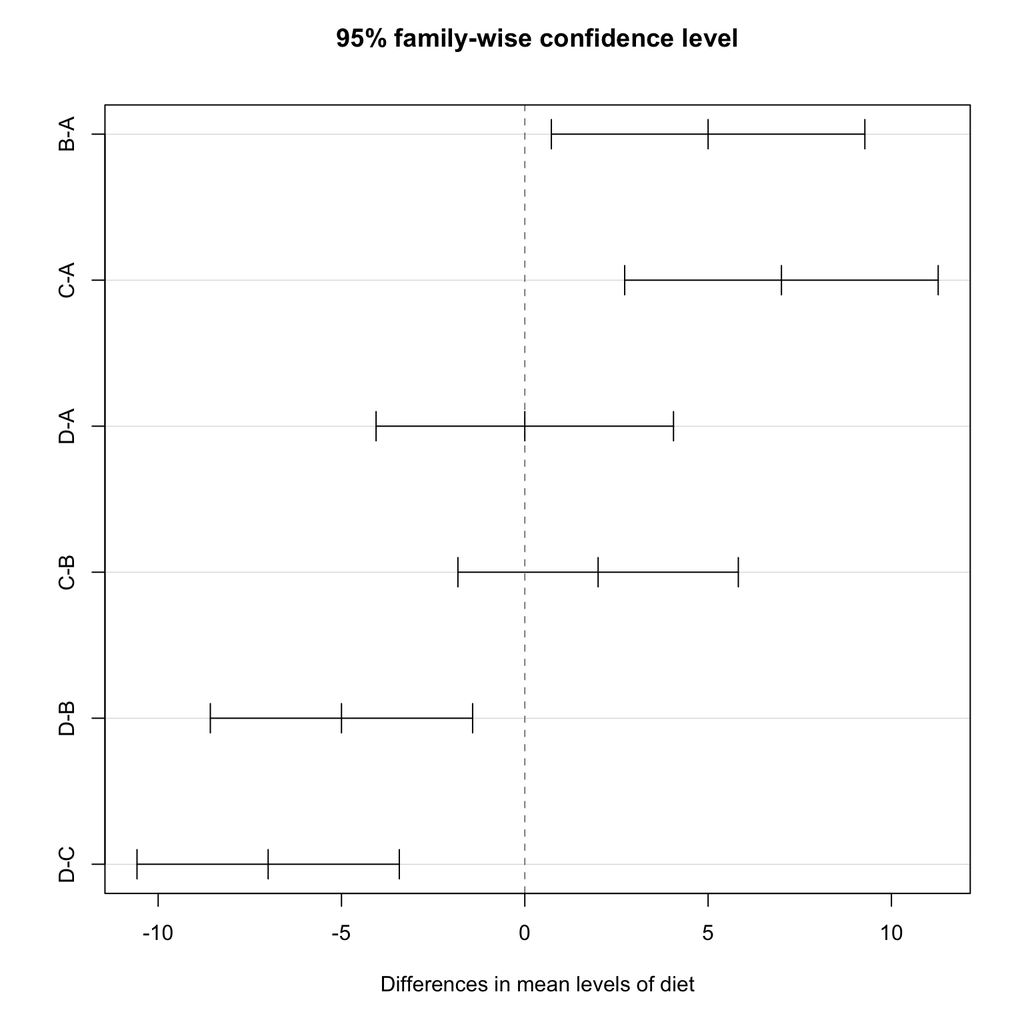

```r
plot (dmeans.tukey)
```

# 7 A complete R Procedure for Example 3.1 from Textbook

```r
## create data frame
poweretch <- data.frame (etch = scan ("data/etchrate.txt"),
                         power = as.factor(rep(c(160, 180, 200, 220),each = 5)))
poweretch
```

| etch | power |
| --- | --- |
| 575 | 160 |
| 542 | 160 |
| 530 | 160 |
| 539 | 160 |
| 570 | 160 |
| 565 | 180 |
| 593 | 180 |
| 590 | 180 |
| 579 | 180 |
| 610 | 180 |
| 600 | 200 |
| 651 | 200 |
| 610 | 200 |
| 637 | 200 |
| 629 | 200 |
| 725 | 220 |
| 700 | 220 |
| 715 | 220 |
| 685 | 220 |
| 710 | 220 |

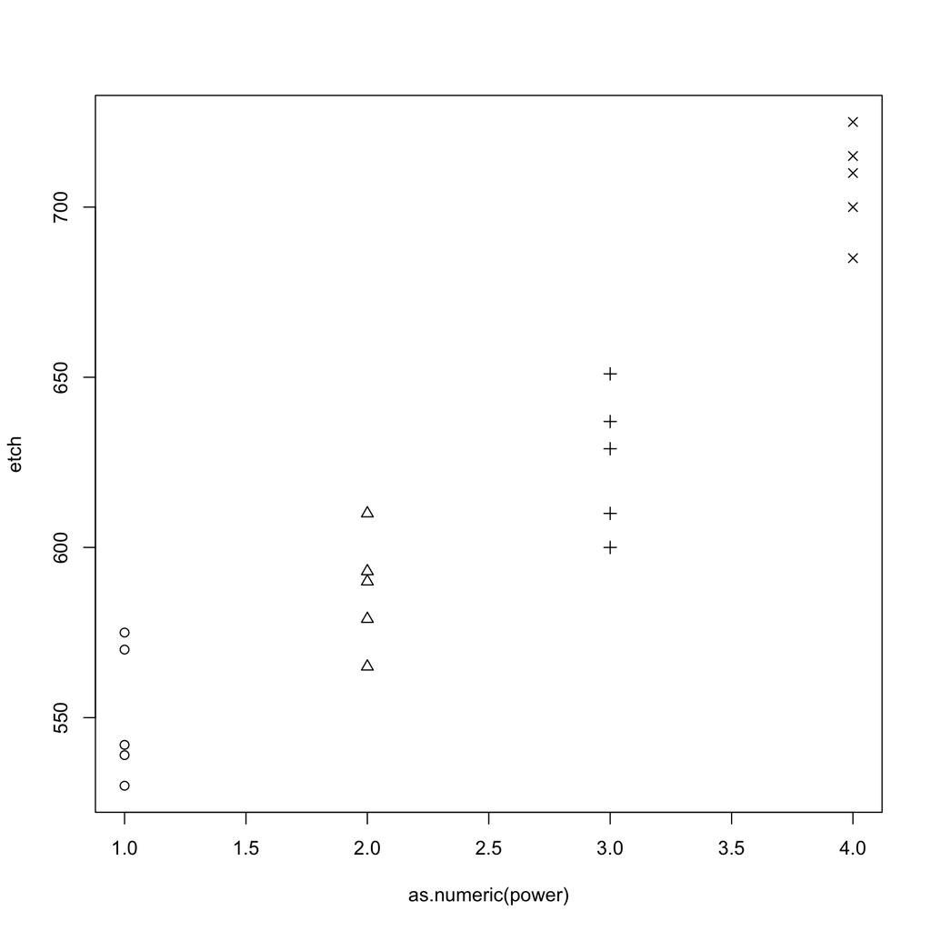

```r
## scatterplot
with (poweretch, plot(as.numeric(power), etch, pch = as.numeric (power)))
```

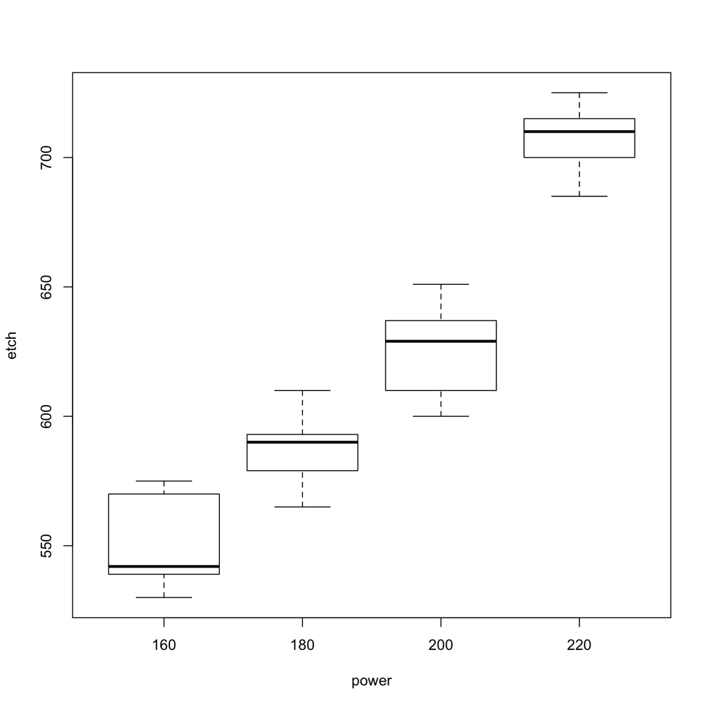

```r
## boxplot
boxplot (etch~power, data = poweretch)
```

```r
## anova analysis
fit.etch <- lm (etch~power, data = poweretch)
summary (fit.etch)
```

```
#
# Call:
# lm(formula = etch ~ power, data = poweretch)
#
# Residuals:
#    Min     1Q Median     3Q    Max
#  -25.4  -13.0    2.8   13.2   25.6
#
# Coefficients:
#             Estimate Std. Error t value Pr(>|t|)
# (Intercept)   551.20       8.17   67.47  < 2e-16 ***
# power180       36.20      11.55    3.13   0.0064 **
# power200       74.20      11.55    6.42  8.4e-06 ***
# power220      155.80      11.55   13.49  3.7e-10 ***
# ---
# Signif. codes:  0 '***' 0.001 '**' 0.01 '*' 0.05 '.' 0.1 ' ' 1
#
# Residual standard error: 18.3 on 16 degrees of freedom
# Multiple R-squared:  0.926,   Adjusted R-squared:  0.912
# F-statistic: 66.8 on 3 and 16 DF,  p-value: 2.88e-09
```

```r
anova(fit.etch)
```

|  | Df | Sum Sq | Mean Sq | F value | Pr(>F) |
| --- | --- | --- | --- | --- | --- |
| power | 3 | 66871 | 22290.2 | 66.8 | 0 |
| Residuals | 16 | 5339 | 333.7 | NA | NA |

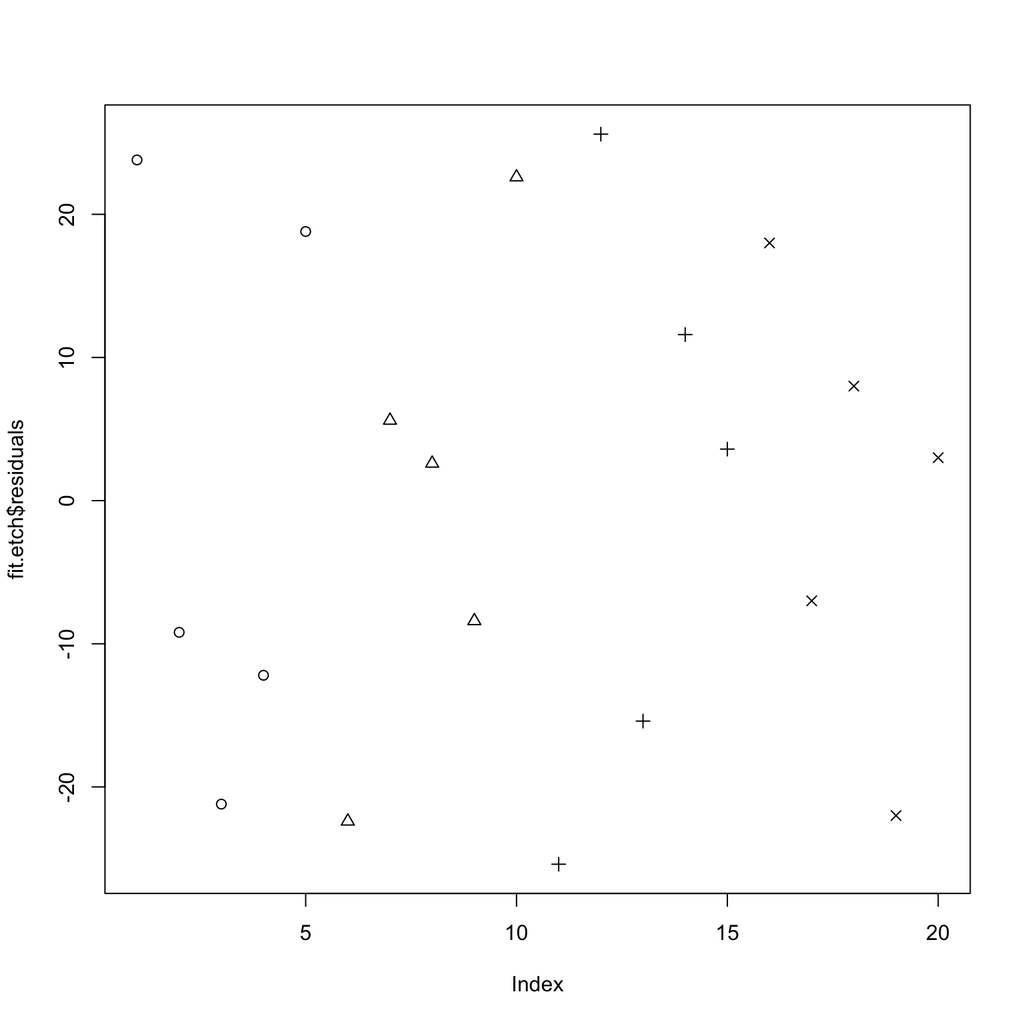

```r
## visualize residuals
plot (fit.etch$residuals, pch = as.numeric(poweretch$power))
```

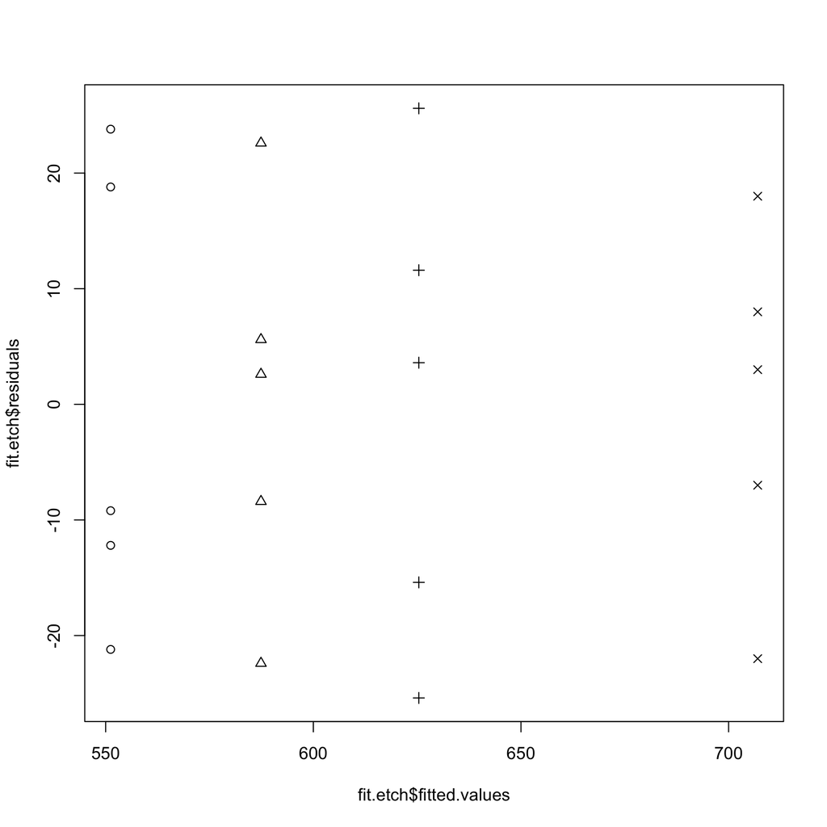

```r
plot (fit.etch$fitted.values, fit.etch$residuals,
      pch = as.numeric(poweretch$power))
```

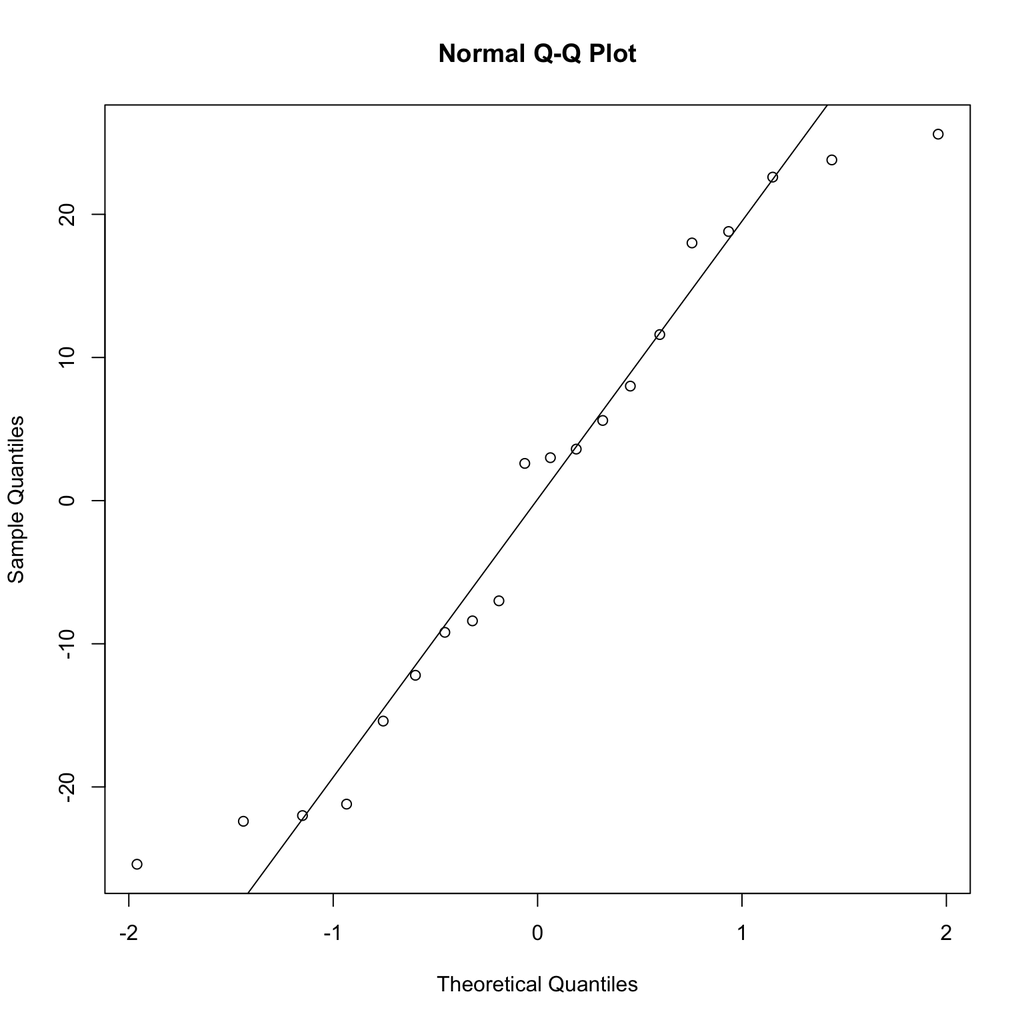

```r
## checking normality of residuals
qqnorm (fit.etch$residuals)
qqline(fit.etch$residuals)
```

```r
shapiro.test(fit.etch$residuals)
```

```
#
#   Shapiro-Wilk normality test
#
# data:  fit.etch$residuals
# W = 0.94, p-value = 0.2
```

```r
## testing equality of variances
with (poweretch, levene.test (etch, power))
```

```
#
#   Modified robust Brown-Forsythe Levene-type test based on the absolute
#   deviations from the median
#
# data:  etch
# Test Statistic = 0.2, p-value = 0.9
```

```r
bartlett.test (etch~power, data = poweretch)
```

```
#
#   Bartlett test of homogeneity of variances
#
# data:  etch by power
# Bartlett's K-squared = 0.43, df = 3, p-value = 0.9
```

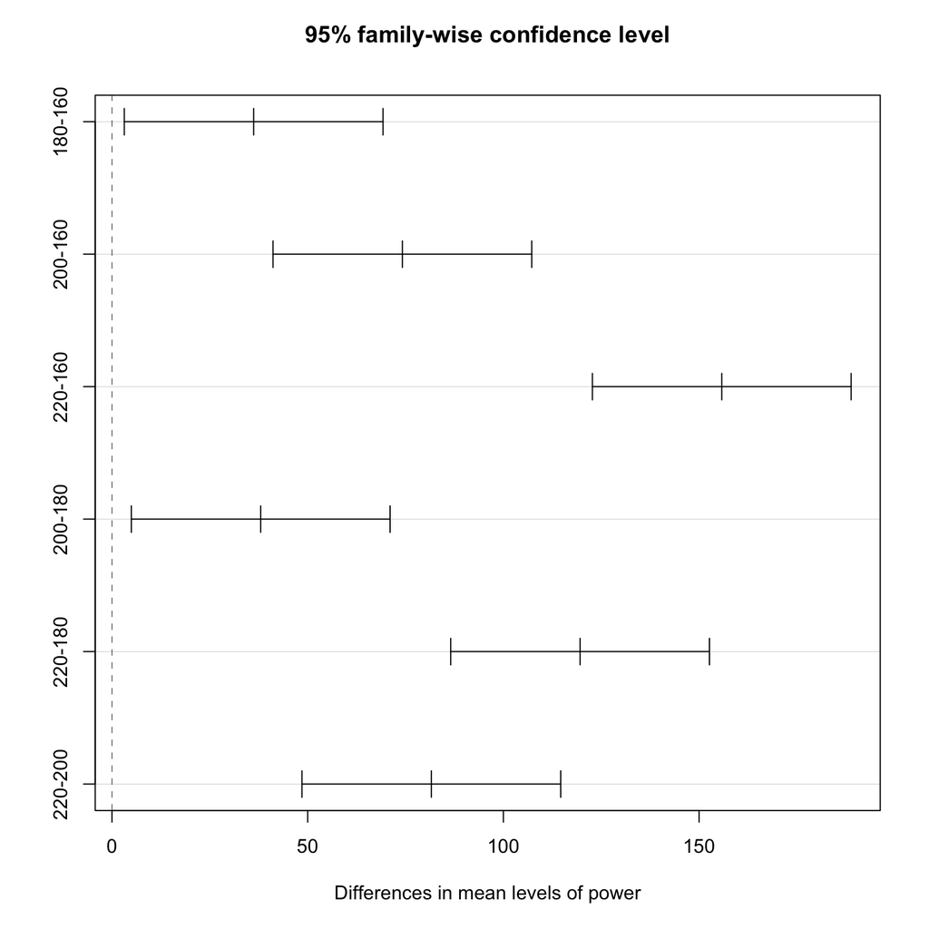

```r
## multiple comparison for assessing pair difference
plot(TukeyHSD(aov(etch~power, data = poweretch)))
```

```r
## look at the difference of a fixed pair of treatments
confint (fit.etch)
```

```
#              2.5 % 97.5 %
# (Intercept) 533.88 568.52
# power180     11.71  60.69
# power200     49.71  98.69
# power220    131.31 180.29
```

```r
## change baseline level
poweretch$n.power <- factor(poweretch$power, levels = paste0(c(200, 180, 160, 220)))
fit.etch2 <- with(poweretch,lm (etch~n.power))
summary (fit.etch2)## looking at test result
```

```
#
# Call:
# lm(formula = etch ~ n.power)
#
# Residuals:
#    Min     1Q Median     3Q    Max
#  -25.4  -13.0    2.8   13.2   25.6
#
# Coefficients:
#             Estimate Std. Error t value Pr(>|t|)
# (Intercept)   625.40       8.17   76.55  < 2e-16 ***
# n.power180    -38.00      11.55   -3.29   0.0046 **
# n.power160    -74.20      11.55   -6.42  8.4e-06 ***
# n.power220     81.60      11.55    7.06  2.7e-06 ***
# ---
# Signif. codes:  0 '***' 0.001 '**' 0.01 '*' 0.05 '.' 0.1 ' ' 1
#
# Residual standard error: 18.3 on 16 degrees of freedom
# Multiple R-squared:  0.926,   Adjusted R-squared:  0.912
# F-statistic: 66.8 on 3 and 16 DF,  p-value: 2.88e-09
```

```r
confint(fit.etch2)
```

```
#              2.5 % 97.5 %
# (Intercept) 608.08 642.72
# n.power180  -62.49 -13.51
# n.power160  -98.69 -49.71
# n.power220   57.11 106.09
```